# NYC Bikes - PDA

John Hios

21/04/2022

# 1 Documentation

## 1.1 Domain knowledge

New York Citi Bike Share is the largest bike share operator in the USA, with 20,000 bikes and over 1,300 stations across Manhattan, Brooklyn, Queens, the Bronx and Jersey City. The Citi Bike program was launched in May 2013 and has become an essential part of New York City’s transportation network.

Citi Bike is available for use 24 hours/day, 7 days/week, 365 days/year, and riders have access to thousands of bikes at hundreds of stations across Manhattan, Brooklyn, Queens and Jersey City. Daily, three-day, and annual passes are available, making Citi Bike a great option for visitors and locals alike.

## 1.2 Business requirements

The following steps are taken to complete this report:

- Data Review
- Data Cleaning/wrangling
- Data Visualisations with an aim to provide actionable insights for increasing bike hires.

## 1.3 Business processes and data flow

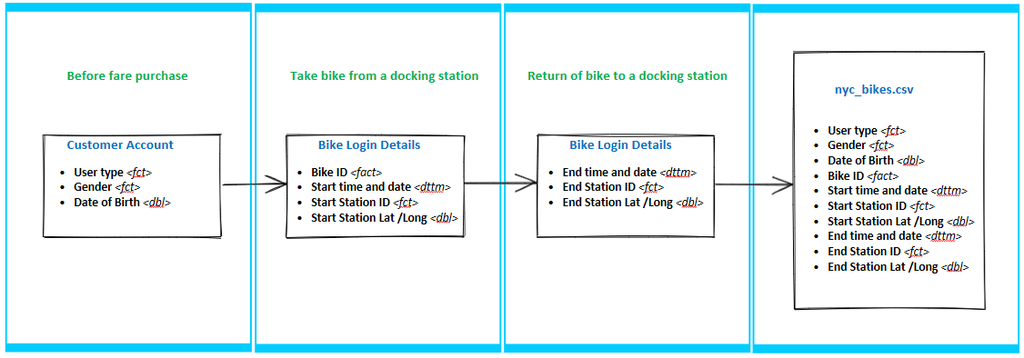

## 1.4 Data visualisation as a tool for decision-making

This report aims at answering the following questions:

- What is the pattern of bike hires over time (e.g. within a year, month, week, or day)? Identifying the periods where bike hiring demand peaks will enable Citi Bikes to manage effectively their fleet. Citi Bikes may withdraw part of the fleet from the streets during quiet periods or increase the number of bikes during busy periods, create scheduled bike inspection/maintenance programmes annual/biannual etc, schedule the replacement of old bikes with new ones).
- Do bike hire patterns differ between bike rider demographics? (e.g. gender, type of trip, age). Patterns and differences in demographics may identify opportunities for attracting new customers via targeted advertising campaigns.
- What is the geographical spread of the start points of bike hires? Knowledge of the geographical spread of the bike hires may help Citi Bikes to identify locations/areas of future expansion.
- What is the predicted bike use over the next couple of months? This information may help Citi Bikes to plan ahead with the short term management of their fleet with a view to identify opportunities for arranging inspection/maintenance checks of the bikes, withdraw/increase the presence of the bike fleet in the streets.

## 1.5 Data quality and data bias

The acquired data meet the following ethical considerations:

- Ownership: Client data abide to the Lyft Privacy Policy (https://www.lyft.com/privacy#privacy-the-information-we-collect) who operates the Citi Bike bicycle sharing service. Citi Bikes owns all right, title, and interest in the Data. The data is provided according to the Citi Bike Data Use Policy (https://ride.citibikenyc.com/data-sharing-policy).
- Transparency: The Citi Bike Data Use Policy in place details how the data may be used. Developers, engineers, statisticians, artists, academics and other interested members of the public are welcome to use the data for the purpose of analysis, development, visualisation and so on.
- Privacy: The customer data published by Citi Bikes are anonymous and there no pieces of personal identifiable information (PII) in the data.
- Intention: Citi Bikes is collecting the minimum viable amount of customer data, so it is taking as little as possible from its customers while providing a rich data source for investigation.

# 2 Cleaning/wrangling

Load libraries:

```r
library(tidyverse)
library(tsibbledata)
library(tsibble)
library(lubridate)
library(slider)
library(e1071)
library(ggthemes)
library(leaflet)
library(fable)
```

View the data:

```
## Rows: 4,268
## Columns: 12
## Key: bike_id [10]
## $ bike_id       <fct> 26301, 26301, 26301, 26301, 26301, 26301, 26301, 26301, ~
## $ start_time    <dttm> 2018-02-26 19:11:03, 2018-02-27 07:52:49, 2018-02-27 12~
## $ stop_time     <dttm> 2018-02-26 19:15:40, 2018-02-27 07:58:13, 2018-02-27 12~
## $ start_station <fct> 3186, 3203, 3202, 3638, 3638, 3187, 3638, 3639, 3202, 36~
## $ start_lat     <dbl> 40.71959, 40.72760, 40.72722, 40.72429, 40.72429, 40.721~
## $ start_long    <dbl> -74.04312, -74.04425, -74.03376, -74.03548, -74.03548, -~
## $ end_station   <fct> 3203, 3202, 3638, 3638, 3187, 3638, 3639, 3202, 3638, 32~
## $ end_lat       <dbl> 40.72760, 40.72722, 40.72429, 40.72429, 40.72112, 40.724~
## $ end_long      <dbl> -74.04425, -74.03376, -74.03548, -74.03548, -74.03805, -~
## $ type          <fct> Subscriber, Subscriber, Subscriber, Subscriber, Subscrib~
## $ birth_year    <dbl> 1986, 1979, 1963, 1984, 1980, 1980, 1989, 1962, 1992, 19~
## $ gender        <fct> Male, Male, Male, Male, Male, Male, Male, Male, Male, Ma~
```

```
## [1] "start_time"
```

```
## [1] "bike_id"
```

```
## <Interval[0]>
```

Use the data in column `start_time` to create `date`, `month` and `year` columns:

| bike_id | start_time | stop_time | start_station | start_lat | start_long | end_station | end_lat | end_long | type | birth_year | gender | day | month | year |
| --- | --- | --- | --- | --- | --- | --- | --- | --- | --- | --- | --- | --- | --- | --- |
| 26301 | 2018-02-26 19:11:03 | 2018-02-26 19:15:40 | 3186 | 40.71959 | -74.04312 | 3203 | 40.72760 | -74.04425 | Subscriber | 1986 | Male | 26 | February | 2018 |
| 26301 | 2018-02-27 07:52:49 | 2018-02-27 07:58:13 | 3203 | 40.72760 | -74.04425 | 3202 | 40.72722 | -74.03376 | Subscriber | 1979 | Male | 27 | February | 2018 |
| 26301 | 2018-02-27 12:03:27 | 2018-02-27 12:04:54 | 3202 | 40.72722 | -74.03376 | 3638 | 40.72429 | -74.03548 | Subscriber | 1963 | Male | 27 | February | 2018 |
| 26301 | 2018-02-27 13:53:51 | 2018-02-27 14:21:04 | 3638 | 40.72429 | -74.03548 | 3638 | 40.72429 | -74.03548 | Subscriber | 1984 | Male | 27 | February | 2018 |
| 26301 | 2018-02-27 14:30:42 | 2018-02-27 14:33:11 | 3638 | 40.72429 | -74.03548 | 3187 | 40.72112 | -74.03805 | Subscriber | 1980 | Male | 27 | February | 2018 |
| 26301 | 2018-02-27 16:31:04 | 2018-02-27 16:33:27 | 3187 | 40.72112 | -74.03805 | 3638 | 40.72429 | -74.03548 | Subscriber | 1980 | Male | 27 | February | 2018 |
| 26301 | 2018-02-27 17:37:12 | 2018-02-27 17:40:49 | 3638 | 40.72429 | -74.03548 | 3639 | 40.71925 | -74.03423 | Subscriber | 1989 | Male | 27 | February | 2018 |
| 26301 | 2018-02-27 17:49:10 | 2018-02-27 17:55:03 | 3639 | 40.71925 | -74.03423 | 3202 | 40.72722 | -74.03376 | Subscriber | 1962 | Male | 27 | February | 2018 |
| 26301 | 2018-02-27 18:21:57 | 2018-02-27 18:25:18 | 3202 | 40.72722 | -74.03376 | 3638 | 40.72429 | -74.03548 | Subscriber | 1992 | Male | 27 | February | 2018 |
| 26301 | 2018-02-27 22:08:55 | 2018-02-27 22:28:42 | 3638 | 40.72429 | -74.03548 | 3281 | 40.74591 | -74.05727 | Subscriber | 1981 | Male | 27 | February | 2018 |

[output cut: 4258 more lines]

Check if data set has NA values:

| year | bike_id | start_time | stop_time | start_station | start_lat | start_long | end_station | end_lat | end_long | type | birth_year | gender | day | month |
| --- | --- | --- | --- | --- | --- | --- | --- | --- | --- | --- | --- | --- | --- | --- |
| 2018 | 0 | 0 | 0 | 0 | 0 | 0 | 0 | 0 | 0 | 0 | 0 | 0 | 0 | 0 |

No data are missing from the tsibble.

# 3 Visualisations

## 3.1 Geographical spread of the start/end points of bike hires

Start Point locations:

[interactive chart not shown]

End Point Locations:

[interactive chart not shown]

**Conclusions**

1. The data presented are local to New Jersey and not to the whole city of New York.
2. The majority of the start/end points are clustered within downtown Jersey City.

## 3.2 Bike hires patterns over time

### 3.2.1 Aggregating hires over 2018

Ratio of subscribers (annual pass) vs. customers (24 hours/3day pass):

| type | year | bike_hire_counts | bike_hiring_percentage |
| --- | --- | --- | --- |
| Customer | 2018 | 315 | 7.380506 |
| Subscriber | 2018 | 3953 | 92.619494 |

Bike hires gender distribution:

| gender | year | bike_hire_counts | bike_hiring_percentage |
| --- | --- | --- | --- |
| Unknown | 2018 | 269 | 6.302718 |
| Male | 2018 | 3069 | 71.907216 |
| Female | 2018 | 930 | 21.790066 |

Visualisation of gender distribution of bike users (subscribers and customers):

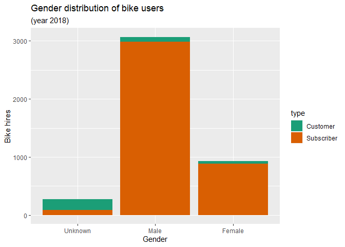

### 3.2.2 Aggregating hires by Quarter

Bike hiring percentages per 2018 Quarters:

| year_quarter | bike_hire_counts | bike_hiring_percentage |
| --- | --- | --- |
| 2018 Q1 | 417 | 9.770384 |
| 2018 Q2 | 1283 | 30.060918 |
| 2018 Q3 | 1797 | 42.104030 |
| 2018 Q4 | 771 | 18.064667 |

Visualisation of gender distribution of bike users (subscribers and customers):

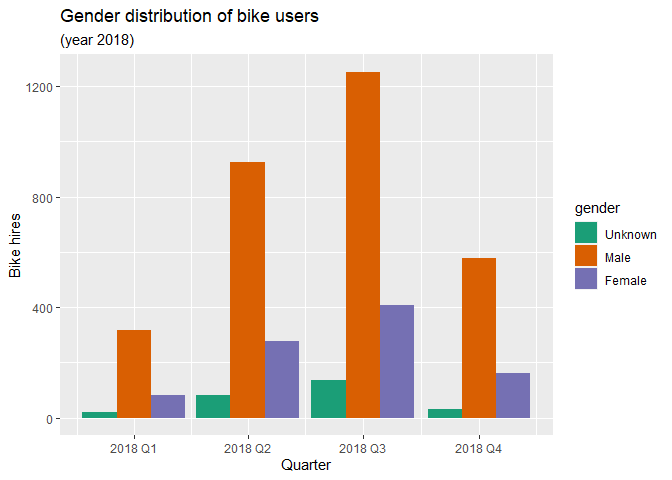

**Conclusions:**

1. The busiest quarter in 2018 was Q3 (Summertime), followed by Q2 .

### 3.2.3 Aggregating hires by month

Bike hiring percentages per month:

| month | bike_hire_counts |
| --- | --- |
| January | 132 |
| February | 112 |
| March | 173 |
| April | 326 |
| May | 459 |
| June | 498 |
| July | 637 |
| August | 728 |
| September | 432 |
| October | 416 |

[output cut: 2 more lines]

Visualisation of gender distribution of bike users (subscribers and customers):

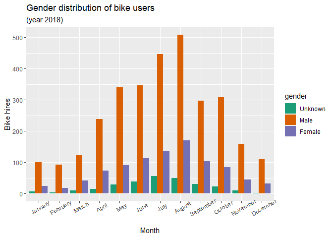

**Conclusions**

1. The data show evidence of seasonality (a comparison of the 2018 trends with data from previous years would be required to confirm this).
2. The busiest month in 2018 was August, followed closely by July.
3. During wintertime (Dec to Feb) bike hires are flat, business picks up during spring, it peaks in August, and starts to drop in fall.

## 3.3 Hire patterns vs. rider demographics

Breakdown of rider age distributions by gender and type of hiring:

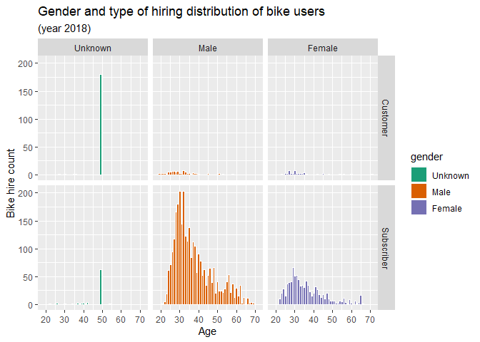

Measures of distribution centrality (mean, median and mode) vs gender:

| gender | year | mean_age | median_age | mode_age | skew_age |
| --- | --- | --- | --- | --- | --- |
| Unknown | 2018 | 47.83146 | 49 | 49 | -3.919767 |
| Male | 2018 | 37.05735 | 34 | 32 | 0.953435 |
| Female | 2018 | 35.86452 | 33 | 29 | 1.141460 |

**Conclusions**

1.The male/female distributions have a similar shape although the statistics (mean, median and mode) for the male riders are slightly higher than the females.

2.The `Unknown` gender distribution has a prominent mode at 49 years for `customers` and `subscribers`. This is not a random error.

## 3.4 Time series analysis

### 3.4.1 Trend plots of `customers` and `subscribers` for 2018:

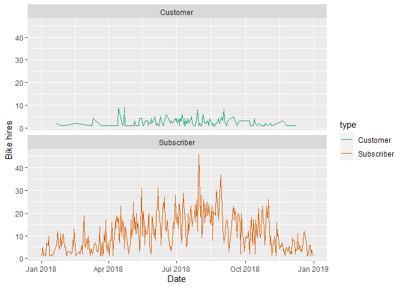

### 3.4.2 Bike use prediction over Jan-Feb 2019:

Bike hires aggregated by week and forecasting via ARIMA modeling:

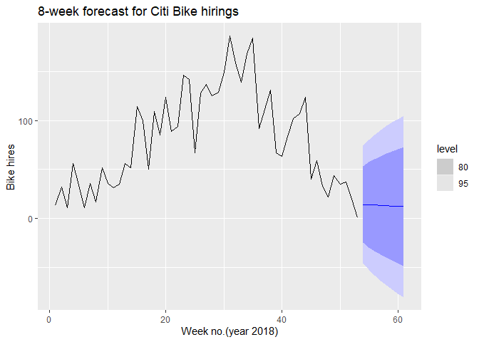

**Conclusions**

1. The `customer` trend plot does not exhibit any seasonality - the bike hiring is fairly constant throughout the course of 2018.
2. The `subscriber` data show evidence of seasonality (a comparison of the 2018 trends with data from previous years would be required to confirm this).
3. Negative values in the forecasting confidence intervals have no actual meaning - it is the way the forecasting model calculates the intervals.
4. The accuracy of the forecasting trend can be improved if more data from previous years were available to model the seasonal component.

# 4 Main Insights

1. There are very few `customers` compared to the annual `subscribers`. Converting `customers` to `subscribers` is not building a strong business case for Citi Bike.
2. The number of male riders is much bigger than the number of females. Citi Bike can focus on attracting more females to use the bikes.
3. The bike scheme is more popular to young ages, mainly below 40. Citi Bike could launch a campaign to attract more senior citizens to use bikes.